# Sesión 7 - Modelos de Vectores Autorregresivos

## 2.3. Validación de supuestos

Para la verificación de supuestos en series multivariadas, usamos las siguientes pruebas.

**No autocorrelación serial:**

Usamos la prueba serial.test(), donde “PT.asymptotic” es para muestra grande y “PT.adjusted” para muestra pequeña.

```r
P.75=serial.test(V.no, lags.pt = 75, type = "PT.asymptotic");P.75 # No rechazo
```

```
##
##  Portmanteau Test (asymptotic)
##
## data:  Residuals of VAR object V.no
## Chi-squared = 211.34, df = 296, p-value = 0.9999
```

```r
P.30=serial.test(V.no, lags.pt = 30, type = "PT.asymptotic");P.30 # No rechazo
```

```
##
##  Portmanteau Test (asymptotic)
##
## data:  Residuals of VAR object V.no
## Chi-squared = 92.137, df = 116, p-value = 0.95
```

```r
P.20=serial.test(V.no, lags.pt = 20, type = "PT.asymptotic");P.20 # No rechazo
```

```
##
##  Portmanteau Test (asymptotic)
##
## data:  Residuals of VAR object V.no
## Chi-squared = 62.165, df = 76, p-value = 0.8736
```

Veamos que para los rezagos seleccionados, se cumple el supuesto de no autocorrelación serial mediante la prueba formal.

Graficamos los residuales para 20 pasos adelante: se grafican los residuales, su distribución, la ACF y PACF de los residuales y a ACF y PACF de los residuales al cuadrado (proxy para heterocedasticidad)

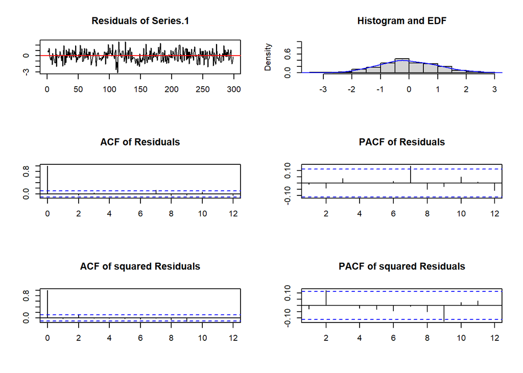

```r
plot(P.20, names = "Series.1")
```

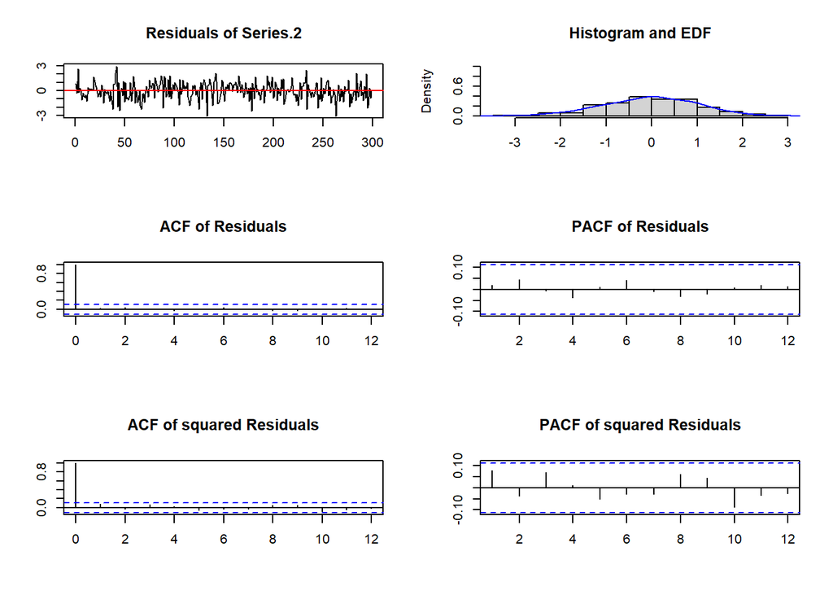

```r
plot(P.20, names = "Series.2")
```

Los residuales de la primera y segunda serie se comportan bien.

**Homocedasticidad:**

Para la homocedasticidad usamos el test ARCH multivariado.

```r
arch.test(V.no, lags.multi = 24, multivariate.only = TRUE)
```

```
##
##  ARCH (multivariate)
##
## data:  Residuals of VAR object V.no
## Chi-squared = 234.46, df = 216, p-value = 0.1851
```

```r
arch.test(V.no, lags.multi = 12, multivariate.only = TRUE)
```

```
##
##  ARCH (multivariate)
##
## data:  Residuals of VAR object V.no
## Chi-squared = 122.23, df = 108, p-value = 0.1651
```

No se rechaza la prueba, se cumple el supuesto de homocedasticidad.

**Normalidad**

Para la normalidad, usamos el test Jarque-Bera para series multivariadas.

```r
normality.test(V.no)
```

```
## $JB
##
##  JB-Test (multivariate)
##
## data:  Residuals of VAR object V.no
## Chi-squared = 1.7368, df = 4, p-value = 0.784
##
##
## $Skewness
##
##  Skewness only (multivariate)
##
## data:  Residuals of VAR object V.no
## Chi-squared = 1.5414, df = 2, p-value = 0.4627
##
##
## $Kurtosis
##
##  Kurtosis only (multivariate)
##
## data:  Residuals of VAR object V.no
## Chi-squared = 0.19542, df = 2, p-value = 0.9069
```

No se rechaza la prueba, se cumple normalidad.

## 2.4. Pronóstico y funciones de impulso respuesta

Algunos usos del modelo son: Pronósticos, Análisis de impulso respuesta, Descomposición de varianza, causalidad de Granger e identificación de un SVAR. Aquí enfatizaremos únicamente en los primeros tres.

**Pronóstico:**

Generamos la predicción para 12 pasos adelante, y fijamos intervalos al 95% de confianza.

```r
predict(V.no, n.ahead = 12,ci=0.95)
```

```
## $Series.1
##              fcst     lower    upper       CI
##  [1,] -0.72002982 -2.682040 1.241980 1.962010
##  [2,] -0.54199386 -2.628973 1.544985 2.086979
##  [3,] -0.42254325 -2.563612 1.718526 2.141069
##  [4,] -0.33207523 -2.504547 1.840397 2.172472
##  [5,] -0.26144467 -2.453010 1.930121 2.191565
##  [6,] -0.20591860 -2.409226 1.997389 2.203308
##  [7,] -0.16219952 -2.372759 2.048360 2.210560
##  [8,] -0.12776502 -2.342812 2.087282 2.215047
##  [9,] -0.10064131 -2.318468 2.117185 2.217826
## [10,] -0.07927586 -2.298825 2.140273 2.219549
## [11,] -0.06244616 -2.283064 2.158172 2.220618
## [12,] -0.04918929 -2.270470 2.172091 2.221280
##
## $Series.2
##             fcst     lower     upper       CI
##  [1,] -1.7338902 -3.760782 0.2930018 2.026892
##  [2,] -1.3831312 -3.904729 1.1384668 2.521598
##  [3,] -1.0925240 -3.884600 1.6995525 2.792076
##  [4,] -0.8611158 -3.809946 2.0877148 2.948831
##  [5,] -0.6783989 -3.720630 2.3638326 3.042232
##  [6,] -0.5343957 -3.633193 2.5644013 3.098797
##  [7,] -0.4209502 -3.554335 2.7124351 3.133385
##  [8,] -0.3315860 -3.486242 2.8230705 3.154656
##  [9,] -0.2611927 -3.428976 2.9065904 3.167783
## [10,] -0.2057434 -3.381644 2.9701574 3.175901
## [11,] -0.1620656 -3.342993 3.0188616 3.180927
## [12,] -0.1276602 -3.311702 3.0563818 3.184042
```

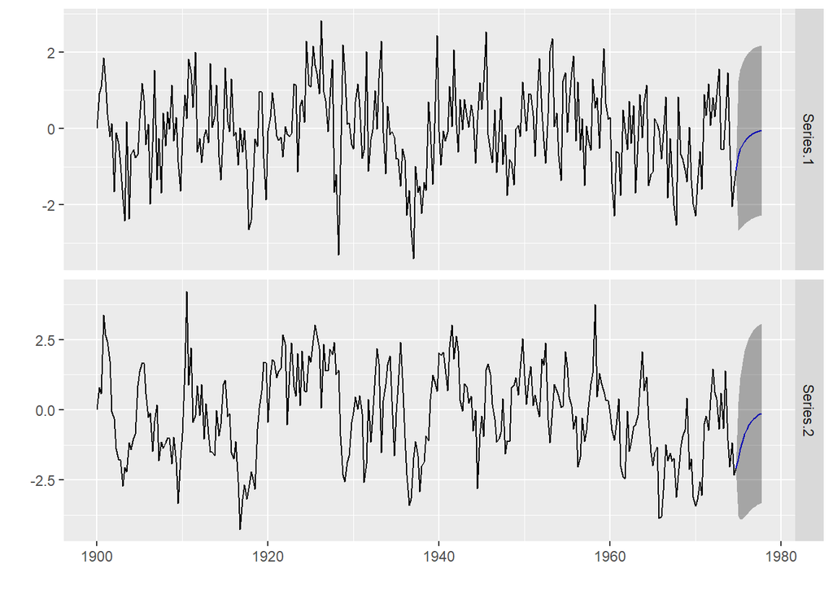

```r
autoplot(predict(V.no, n.ahead = 12,ci=0.95))
```

Como el proceso tiene media cero, el pronóstico converge a la media.

Con Fanchart, podremos regiones de probabilidad para el pronóstico: las zonas más oscuras son más probables.

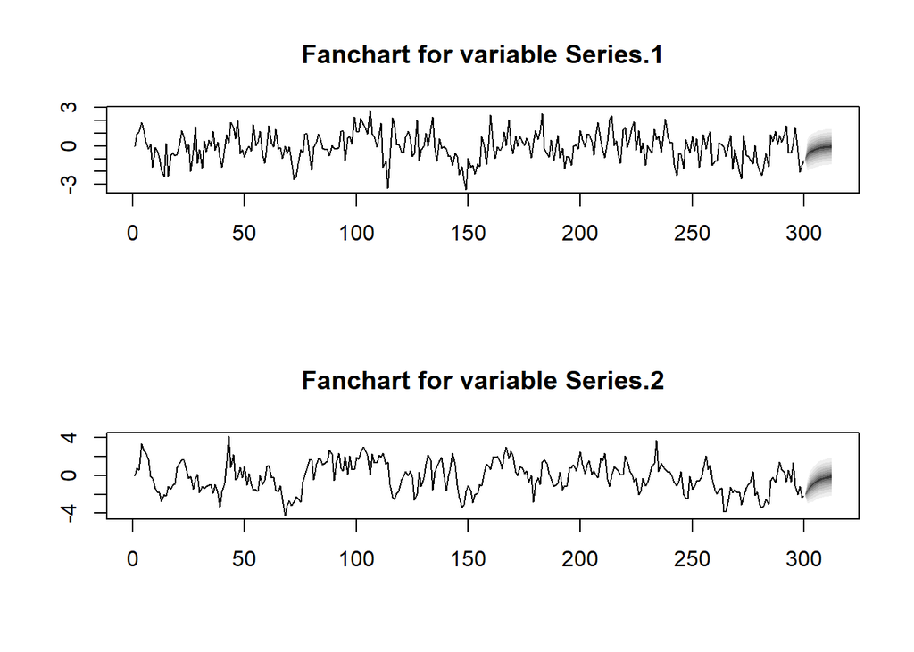

```r
fanchart(predict(V.no, n.ahead = 12))
```

**Gráficas Impulso respuesta:**

Análisis Impulso Respuesta: ¿Qué efecto tiene un choque exógeno sobre una variable sobre las variables del sistema? todos los choques exógenos se incorporan/capturan en los residuales. Se parte del supuesto de Ceteris Paribus: los choques de una variable no deben correlacionarse con el de otra. Las funciones de impulso respuesta nos mostraran como reacciona una determinada variable ante un choque exógeno en otra variable de la serie multivariada (esta otra variable puede ser ella misma).

Similar a un pronóstico, fijamos un número de pasos adelante para analizar el efecto de las funciones impulso respuesta en un periodo determinado.

```r
pasos_adelante = 0:18
```

Función para gráficar las funciones impulso respuesta

```r
impulso_respuesta = function(var, impulso, respuesta, pasos_adelante, ortog, int_conf, titulo){
  # Cáclulo de la función impulso respuesta
  total_pasos_futuros = length(pasos_adelante) - 1
  IRF = irf(var, impulse=impulso, response=respuesta, n.ahead = total_pasos_futuros, ortho=ortog, ci = int_conf)
  IRF_data_frame = data.frame(IRF$irf,IRF$Lower,IRF$Upper, pasos_adelante)
  # Gráfica de la función impulso respuesta
  graph = IRF_data_frame %>%
    ggplot(aes(x=IRF_data_frame[,4], y=IRF_data_frame[,1], ymin=IRF_data_frame[,2], ymax=IRF_data_frame[,3] )) +
    geom_hline(yintercept = 0, color="red") +
    geom_ribbon(fill="grey", alpha=0.2) +
    geom_line() +
    theme_light() +
    ggtitle(titulo)+
    ylab("")+
    xlab("pasos adelante") +
    theme(plot.title = element_text(size = 11, hjust=0.5),
          axis.title.y = element_text(size=11))
  return(graph)
}
```

Una vez llamada la función, calculamos las posibles IRF de la serie multivariada. Si tenemos dos series individuales en el sistema, es de esperarse obtener cuatro gráficas de IRF.

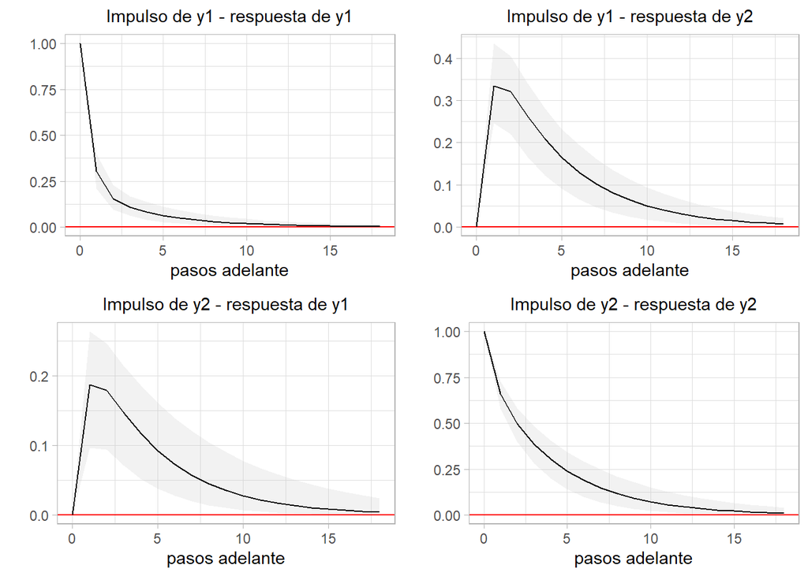

```r
y1.y1 = impulso_respuesta(V.no, "Series.1", "Series.1", pasos_adelante, ortog = F,
                          int_conf = 0.95, titulo = "Impulso de y1 - respuesta de y1")
y1.y2 = impulso_respuesta(V.no, "Series.1", "Series.2", pasos_adelante, ortog = F,
                          int_conf = 0.95, titulo = "Impulso de y1 - respuesta de y2")
y2.y1 = impulso_respuesta(V.no, "Series.2", "Series.1", pasos_adelante, ortog = F,
                          int_conf = 0.95, titulo = "Impulso de y2 - respuesta de y1")
y2.y2 = impulso_respuesta(V.no, "Series.2", "Series.2", pasos_adelante, ortog = F,
                          int_conf = 0.95, titulo = "Impulso de y2 - respuesta de y2")

grid.arrange(y1.y1,y1.y2,y2.y1,y2.y2, ncol = 2)
```

Sin embargo, aquí hemos obtenido las IRF sin ortogonalizar.

¿Qué son las respuestas ortogonalizadas? Como les mencionamos anteriormente, u_1 y u_2 (aunque individualmente son ruido blanco) están correlacionados de forma contemporánea (en el periodo t), de manera que los choques entre las variables posiblemente también estén correlacionados. Por lo tanto, las funciones impulso-respuesta ortogonales hacen una transformación de la matriz de varianzas y covarianzas de los residuales, de forma que ya no estén correlacionados (se hace a partir de la descomposición de choleski), y por ende, los choques entre las variables tampoco. La interpretación es exactamente la misma, sin embargo, el ordenamiento de las variables importa: la primera variable afecta contemporáneamente a todas las variables del sistema, mientras la segunda variable afecta contemporáneamente a todas las variables menos a la primera, la tercera afecta a todas menos a la primera y la segunda variable, etc…

Para el calculo de las funciones impuslo respuesta ortogonalizadas lo único que hay que hacer es cambiar el parámetro ortog=F a ortog=T.

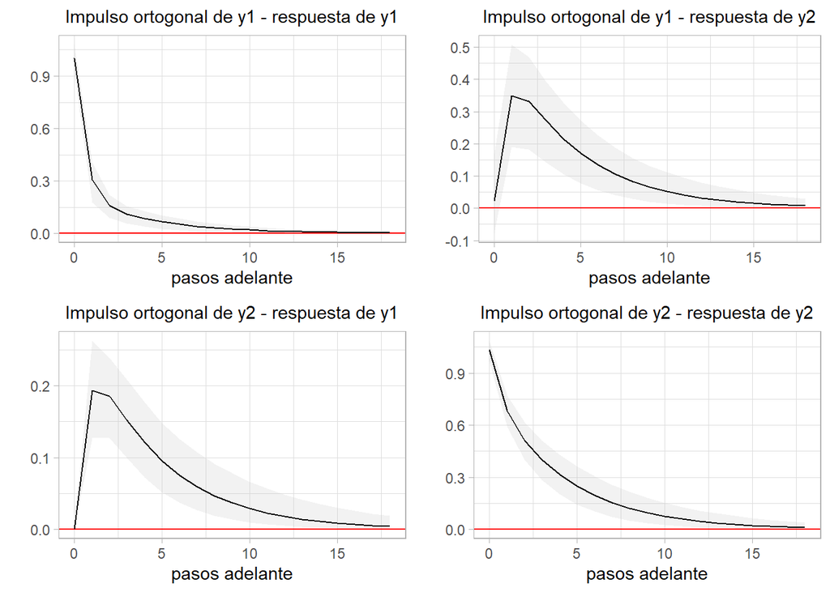

```r
y1.y1. = impulso_respuesta(V.no, "Series.1", "Series.1", pasos_adelante, ortog = T,
                           int_conf = 0.95, titulo = "Impulso ortogonal de y1 - respuesta de y1")
y1.y2. = impulso_respuesta(V.no, "Series.1", "Series.2", pasos_adelante, ortog = T,
                           int_conf = 0.95, titulo = "Impulso ortogonal de y1 - respuesta de y2")
y2.y1. = impulso_respuesta(V.no, "Series.2", "Series.1", pasos_adelante, ortog = T,
                           int_conf = 0.95, titulo = "Impulso ortogonal de y2 - respuesta de y1")
y2.y2. = impulso_respuesta(V.no, "Series.2", "Series.2", pasos_adelante, ortog = T,
                           int_conf = 0.95, titulo = "Impulso ortogonal de y2 - respuesta de y2")

grid.arrange(y1.y1.,y1.y2.,y2.y1.,y2.y2., ncol = 2)
```

**Desomposición de la varianza:**

Aquí veremos la proporción de la varianza de error de pronóstico de cada variable explicada por las variables dentro del sistema. Veamos una muestra graficamente.

```r
fevd(V.no, n.ahead = 18)
```

```
## $Series.1
##        Series.1   Series.2
##  [1,] 1.0000000 0.00000000
##  [2,] 0.9671016 0.03289842
##  [3,] 0.9398143 0.06018571
##  [4,] 0.9226809 0.07731911
##  [5,] 0.9123254 0.08767458
##  [6,] 0.9060500 0.09394999
##  [7,] 0.9022189 0.09778108
##  [8,] 0.8998664 0.10013360
##  [9,] 0.8984162 0.10158383
## [10,] 0.8975200 0.10248004
## [11,] 0.8969653 0.10303472
## [12,] 0.8966216 0.10337835
## [13,] 0.8964086 0.10359137
```

[output cut: 26 more lines]

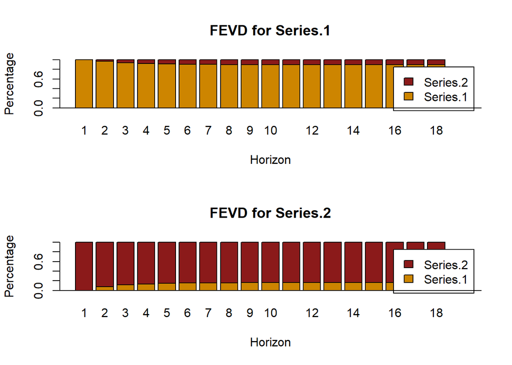

```r
plot(fevd(V.no, n.ahead = 18),col=c("orange3", "firebrick4"))
```

Para ver las funciones de Impulso-Respuesta, veamos la representación VMA del proceso VAR(1) modelado (10 pasos adelante). De esta representación se obtienen las funciones impulso-respuesta al hacer las derivadas parciales respectivas.

```r
Phi(V.no,nstep=10)
```

```
## , , 1
##
##      [,1] [,2]
## [1,]    1    0
## [2,]    0    1
##
## , , 2
##
##           [,1]      [,2]
## [1,] 0.3029154 0.1867972
## [2,] 0.3337365 0.6591138
##
## , , 3
##
##           [,1]      [,2]
## [1,] 0.1540988 0.1797043
## [2,] 0.3210642 0.4967721
##
## , , 4
##
##           [,1]      [,2]
## [1,] 0.1066528 0.1472308
## [2,] 0.2630463 0.3874032
##
## , , 5
##
##            [,1]      [,2]
## [1,] 0.08144306 0.1169643
## [2,] 0.20897135 0.3044791
##
## , , 6
##
##            [,1]       [,2]
## [1,] 0.06370561 0.09230612
## [2,] 0.16491642 0.23972164
##
## , , 7
##
##            [,1]       [,2]
## [1,] 0.05010333 0.07274026
```

[output cut: 10 more lines]

```
##            [,1]       [,2]
## [1,] 0.03107516 0.04513911
## [2,] 0.08064667 0.11714971
##
## , , 10
##
##            [,1]       [,2]
## [1,] 0.02447771 0.03555656
## [2,] 0.06352625 0.09227956
##
## , , 11
##
##            [,1]       [,2]
## [1,] 0.01928120 0.02800819
## [2,] 0.05004014 0.07268926
```

La función psi nos calcula los coeficientes de las matrices de la representación VMA bajo una estrategia de identificación ortogonal. Es decir, son los coeficientes de las IRF ortogonales n pasos adelante.

```r
Psi(V.no, nstep = 10)
```

```
## , , 1
##
##            [,1]     [,2]
## [1,] 1.00104402 0.000000
## [2,] 0.02165798 1.033921
##
## , , 2
##
##           [,1]      [,2]
## [1,] 0.3072773 0.1931334
## [2,] 0.3483600 0.6814714
##
## , , 3
##
##           [,1]      [,2]
## [1,] 0.1581517 0.1858000
## [2,] 0.3321585 0.5136229
##
## , , 4
##
##           [,1]      [,2]
## [1,] 0.1099528 0.1522250
## [2,] 0.2717113 0.4005442
##
## , , 5
##
##           [,1]      [,2]
## [1,] 0.0840613 0.1209318
## [2,] 0.2157839 0.3148073
##
## , , 6
##
##            [,1]       [,2]
## [1,] 0.06577128 0.09543721
## [2,] 0.17028049 0.24785317
##
## , , 7
##
##            [,1]       [,2]
## [1,] 0.05173104 0.07520767
```

[output cut: 10 more lines]

```
##            [,1]       [,2]
## [1,] 0.03208522 0.04667027
## [2,] 0.08326810 0.12112352
##
## , , 10
##
##            [,1]       [,2]
## [1,] 0.02527335 0.03676267
## [2,] 0.06559116 0.09540975
##
## , , 11
##
##            [,1]       [,2]
## [1,] 0.01990793 0.02895825
## [2,] 0.05166668 0.07515493
```

# 3. Ejemplo de Enders

Tenemos series de frecuencia trimestral desde 1960 Q1 - 2012 Q4 para el Índice de Producción Industrial, El índice de precios al consumidor y la tasa de desempleo de Estados Unidos

Partamos de este ejercicios de Enders: “in order to estimate the dynamic effects of aggregate demand and supply shocks on industrial production and the inflation rate. Create the logarithmic change in the index of industrial production (indprod) as Δlipt = ln(indprod) − ln(indprodt−1) and the inflation rate (as measured by CPI) as inft = log(cpit) − log(cpit−1)”

Sin embargo, le incorporaremos la tasa de desempleo para tener un sistema en tres variables.

Definimos la base de datos y las variables nivel

```r
Base = read_excel(file.choose())
attach(Base)

IPI = ts(IPI, start=c(1960,1),frequency=4)
CPI= ts(CPI, start=c(1960,1),frequency=4)
UNEM = ts(Unem, start=c(1960,1),frequency=4)
```

Ahora definimos la variación del CPI y la tasa de crecimiento del IPI

Nota: Inicialmente, este ejemplo iba a ser trabajado con la inflación en vez de la variación del CPI tal como esta propuesto en el libro de Enders. Sin embargo, cuando se trabajaba con la inflación se producián contradicciones en la prueba Dickey-Fuller por lo que el equipo de monitores prefirió usar la tasa de CPI

Recuerden que en sus trabajos pueden guiarse principalmente de la teoría económica. Aquí los resultados fueron ‘sinteticamente’ preparados. Además, no olviden que si quieren calcular la inflación a partir del CPI deben hacer la transformación con logaritmo y diferencia.

```r
dl.IPI = diff(log(IPI))
d.CPI = diff(CPI)
```

Veamos las series gráficas.

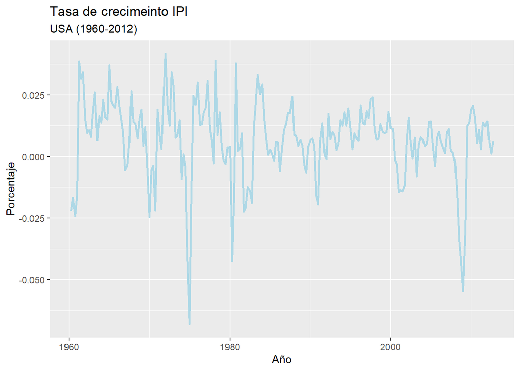

```r
autoplot(dl.IPI, size=1, ts.colour="lightblue", xlab="Año", ylab="Porcentaje",
         main="Tasa de crecimeinto IPI")+labs(subtitle = "USA (1960-2012)")
```

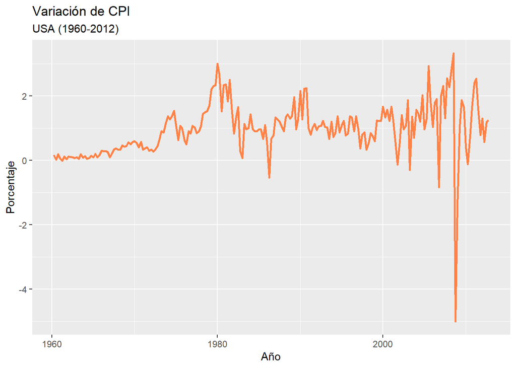

```r
autoplot(d.CPI, size=1, ts.colour="sienna1", xlab="Año",  ylab="Porcentaje",
         main="Variación de CPI")+ labs(subtitle = "USA (1960-2012)")
```

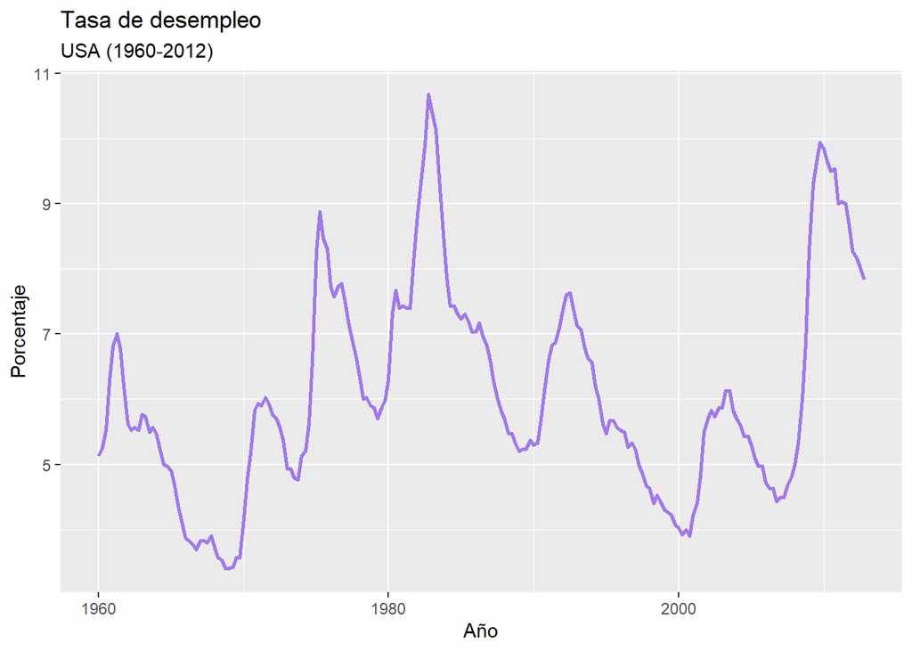

```r
autoplot(UNEM, size=1, ts.colour="mediumpurple2", xlab="Año", ylab="Porcentaje",
         main="Tasa de desempleo")+ labs(subtitle = "USA (1960-2012)")
```

Parecen ser estacionarias, confirmemos con la prueba Dickey-Fuller. Anticipadamente, hacemos la prueba con deriva ya que sabemos que esta es significativa.

```r
#Tasa de crecimiento IPI
adf3= ur.df(dl.IPI, lags=6, selectlags="AIC", type="drift")
summary(adf3) # La serie es estacionaria y con intercepto
```

```
##
## ###############################################
## # Augmented Dickey-Fuller Test Unit Root Test #
## ###############################################
##
## Test regression drift
##
##
## Call:
## lm(formula = z.diff ~ z.lag.1 + 1 + z.diff.lag)
##
## Residuals:
##       Min        1Q    Median        3Q       Max
## -0.047176 -0.006197  0.000853  0.006424  0.041268
##
## Coefficients:
##               Estimate Std. Error t value Pr(>|t|)
## (Intercept)  0.0030445  0.0009988   3.048  0.00262 **
## z.lag.1     -0.4608782  0.0733340  -6.285 2.03e-09 ***
## z.diff.lag1  0.1452351  0.0796346   1.824  0.06969 .
## z.diff.lag2 -0.0553725  0.0724224  -0.765  0.44543
## z.diff.lag3  0.1381686  0.0673885   2.050  0.04164 *
## ---
## Signif. codes:  0 '***' 0.001 '**' 0.01 '*' 0.05 '.' 0.1 ' ' 1
##
## Residual standard error: 0.01221 on 199 degrees of freedom
## Multiple R-squared:  0.2398, Adjusted R-squared:  0.2245
## F-statistic: 15.69 on 4 and 199 DF,  p-value: 3.528e-11
##
##
## Value of test-statistic is: -6.2846 19.7761
##
## Critical values for test statistics:
##       1pct  5pct 10pct
## tau2 -3.46 -2.88 -2.57
## phi1  6.52  4.63  3.81
```

```r
#Tasa de inflación
adf4= ur.df(d.CPI, lags=6, selectlags="AIC", type="drift")
summary(adf4) # La serie es estacionaria y con intercepto.
```

```
##
## ###############################################
## # Augmented Dickey-Fuller Test Unit Root Test #
## ###############################################
##
## Test regression drift
##
##
## Call:
## lm(formula = z.diff ~ z.lag.1 + 1 + z.diff.lag)
##
## Residuals:
##     Min      1Q  Median      3Q     Max
## -6.9923 -0.2621 -0.0668  0.3195  1.5595
##
## Coefficients:
##             Estimate Std. Error t value Pr(>|t|)
## (Intercept)  0.34658    0.10087   3.436 0.000719 ***
## z.lag.1     -0.34354    0.08969  -3.830 0.000172 ***
## z.diff.lag1 -0.23554    0.09302  -2.532 0.012112 *
## z.diff.lag2 -0.32907    0.08855  -3.716 0.000263 ***
## z.diff.lag3 -0.14007    0.07895  -1.774 0.077569 .
## z.diff.lag4 -0.23450    0.06885  -3.406 0.000798 ***
## ---
## Signif. codes:  0 '***' 0.001 '**' 0.01 '*' 0.05 '.' 0.1 ' ' 1
##
## Residual standard error: 0.7242 on 198 degrees of freedom
## Multiple R-squared:  0.3428, Adjusted R-squared:  0.3262
## F-statistic: 20.66 on 5 and 198 DF,  p-value: < 2.2e-16
##
##
## Value of test-statistic is: -3.8301 7.3658
##
## Critical values for test statistics:
##       1pct  5pct 10pct
## tau2 -3.46 -2.88 -2.57
## phi1  6.52  4.63  3.81
```

```r
#Tasa de desempleo
adf5= ur.df(UNEM, lags=6, selectlags="AIC", type="drift")
summary(adf5) # La serie es estacionaria y con intercepto.
```

```
##
## ###############################################
## # Augmented Dickey-Fuller Test Unit Root Test #
## ###############################################
##
## Test regression drift
##
##
## Call:
## lm(formula = z.diff ~ z.lag.1 + 1 + z.diff.lag)
##
## Residuals:
##      Min       1Q   Median       3Q      Max
## -0.71141 -0.15860 -0.02373  0.13326  1.02756
##
## Coefficients:
##             Estimate Std. Error t value Pr(>|t|)
## (Intercept)  0.21490    0.06711   3.202  0.00158 **
## z.lag.1     -0.03508    0.01068  -3.285  0.00120 **
## z.diff.lag   0.67945    0.05185  13.105  < 2e-16 ***
## ---
## Signif. codes:  0 '***' 0.001 '**' 0.01 '*' 0.05 '.' 0.1 ' ' 1
##
## Residual standard error: 0.2473 on 202 degrees of freedom
## Multiple R-squared:  0.464,  Adjusted R-squared:  0.4587
## F-statistic: 87.44 on 2 and 202 DF,  p-value: < 2.2e-16
##
##
## Value of test-statistic is: -3.2852 5.402
##
## Critical values for test statistics:
##       1pct  5pct 10pct
## tau2 -3.46 -2.88 -2.57
## phi1  6.52  4.63  3.81
```

Todas las variables son estacionarias y tienen intercepto. Ahora, con el fin de estimar un VAR, generamos una matriz con las tres variables para crear una serie multivariada.

```r
Unem = UNEM[1:211]
Y = cbind(dl.IPI,Unem,d.CPI)
```

## 3.1. Identificación

Usamos VARselect() para identificar dos posibles modelos VAR, uno con intercepto y otro sin términos determinísticos.

```r
#Selección de rezagos para un VAR con sólo intercepto.
VARselect(Y, lag.max=6,type = "const", season = NULL)
```

```
## $selection
## AIC(n)  HQ(n)  SC(n) FPE(n)
##      3      2      2      3
##
## $criteria
##                    1             2             3             4             5
## AIC(n) -1.268997e+01 -1.296060e+01 -1.299339e+01 -1.297192e+01 -1.296381e+01
## HQ(n)  -1.261129e+01 -1.282292e+01 -1.279670e+01 -1.271621e+01 -1.264910e+01
## SC(n)  -1.249545e+01 -1.262020e+01 -1.250710e+01 -1.233973e+01 -1.218574e+01
## FPE(n)  3.081925e-06  2.351347e-06  2.275847e-06  2.325898e-06  2.345871e-06
##                    6
## AIC(n) -1.291153e+01
## HQ(n)  -1.253781e+01
## SC(n)  -1.198757e+01
## FPE(n)  2.473379e-06
```

```r
#Selección de rezagos para un VAR sin términos determinísticos.
VARselect(Y, lag.max=6,type = "none", season = NULL)
```

```
## $selection
## AIC(n)  HQ(n)  SC(n) FPE(n)
##      5      2      2      5
##
## $criteria
##                    1             2             3             4             5
## AIC(n) -1.263095e+01 -1.285623e+01 -1.287760e+01 -1.286470e+01 -1.288520e+01
## HQ(n)  -1.257195e+01 -1.273822e+01 -1.270057e+01 -1.262867e+01 -1.259016e+01
## SC(n)  -1.248507e+01 -1.256446e+01 -1.243993e+01 -1.228115e+01 -1.215576e+01
## FPE(n)  3.269256e-06  2.609942e-06  2.555079e-06  2.588850e-06  2.537297e-06
##                    6
## AIC(n) -1.283753e+01
## HQ(n)  -1.248348e+01
## SC(n)  -1.196220e+01
## FPE(n)  2.662698e-06
```

Además, nos llama la atención el modelo con constante debido a que es un VAR(3) que es más parsimonioso que un VAR(5). De cierta forma, el criterio de parsimonia no es tan relevante en modelos VAR, no obstante recuerden que si tenemos un VAR(5) con 3 variables y sin inctercepto, estaríamos estimando 9*5 coeficientes por lo menos, lo que hace que se pierda interpretabilidad.

## 3.2. Estimación

Para elegir cuál modelo estimar, vamos a fijarnos en las gráficas de las series (ninguna aparenta tener tendencia), y de la significancia estadística de los términos determinísticos en cada una de las ecuaciones del modelo VAR.

```r
# VAR con sólo intercepto.
V.dr.1= VAR(Y, p=3, type="const", season=NULL)
summary(V.dr.1)
```

```
##
## VAR Estimation Results:
## =========================
## Endogenous variables: dl.IPI, Unem, d.CPI
## Deterministic variables: const
## Sample size: 208
## Log Likelihood: 490.781
## Roots of the characteristic polynomial:
## 0.9138 0.7415 0.7415 0.5542 0.5542 0.4432 0.4432 0.435 0.1727
## Call:
## VAR(y = Y, p = 3, type = "const")
##
##
## Estimation results for equation dl.IPI:
## =======================================
## dl.IPI = dl.IPI.l1 + Unem.l1 + d.CPI.l1 + dl.IPI.l2 + Unem.l2 + d.CPI.l2 + dl.IPI.l3 + Unem.l3 + d.CPI.l3 + const
##
##             Estimate Std. Error t value Pr(>|t|)
## dl.IPI.l1  0.5709307  0.0689119   8.285 1.76e-14 ***
## Unem.l1    0.0029643  0.0050928   0.582  0.56119
## d.CPI.l1  -0.0014196  0.0011302  -1.256  0.21057
## dl.IPI.l2 -0.1403253  0.1025731  -1.368  0.17285
## Unem.l2    0.0008765  0.0080367   0.109  0.91326
## d.CPI.l2  -0.0015595  0.0012292  -1.269  0.20604
## dl.IPI.l3  0.1706382  0.0968647   1.762  0.07968 .
## Unem.l3   -0.0022026  0.0046264  -0.476  0.63453
## d.CPI.l3  -0.0034671  0.0011564  -2.998  0.00306 **
## const     -0.0008862  0.0036373  -0.244  0.80776
## ---
## Signif. codes:  0 '***' 0.001 '**' 0.01 '*' 0.05 '.' 0.1 ' ' 1
##
##
## Residual standard error: 0.01188 on 198 degrees of freedom
## Multiple R-Squared: 0.4553,  Adjusted R-squared: 0.4306
## F-statistic: 18.39 on 9 and 198 DF,  p-value: < 2.2e-16
##
##
## Estimation results for equation Unem:
## =====================================
## Unem = dl.IPI.l1 + Unem.l1 + d.CPI.l1 + dl.IPI.l2 + Unem.l2 + d.CPI.l2 + dl.IPI.l3 + Unem.l3 + d.CPI.l3 + const
```

[output cut: 42 more lines]

```
## F-statistic: 7.233 on 9 and 198 DF,  p-value: 4.527e-09
##
##
##
## Covariance matrix of residuals:
##            dl.IPI       Unem      d.CPI
## dl.IPI  0.0001412 -0.0002385  0.0006285
## Unem   -0.0002385  0.0277930 -0.0194426
## d.CPI   0.0006285 -0.0194426  0.5520232
##
## Correlation matrix of residuals:
##          dl.IPI    Unem    d.CPI
## dl.IPI  1.00000 -0.1204  0.07118
## Unem   -0.12038  1.0000 -0.15697
## d.CPI   0.07118 -0.1570  1.00000
```

```r
# VAR sin términos determinísticos.
V.no.1 = VAR(Y, p=3, type="none", season=NULL)
summary(V.no.1)
```

```
##
## VAR Estimation Results:
## =========================
## Endogenous variables: dl.IPI, Unem, d.CPI
## Deterministic variables: none
## Sample size: 208
## Log Likelihood: 474.832
## Roots of the characteristic polynomial:
## 0.9968 0.7399 0.7399 0.5447 0.5447 0.4858 0.4666 0.4666 0.1269
## Call:
## VAR(y = Y, p = 3, type = "none")
##
##
## Estimation results for equation dl.IPI:
## =======================================
## dl.IPI = dl.IPI.l1 + Unem.l1 + d.CPI.l1 + dl.IPI.l2 + Unem.l2 + d.CPI.l2 + dl.IPI.l3 + Unem.l3 + d.CPI.l3
##
##            Estimate Std. Error t value Pr(>|t|)
## dl.IPI.l1  0.570684   0.068741   8.302 1.55e-14 ***
## Unem.l1    0.002553   0.004794   0.533  0.59490
## d.CPI.l1  -0.001464   0.001112  -1.316  0.18958
## dl.IPI.l2 -0.144900   0.100601  -1.440  0.15134
## Unem.l2    0.001194   0.007912   0.151  0.88023
## d.CPI.l2  -0.001571   0.001226  -1.282  0.20150
## dl.IPI.l3  0.165616   0.094422   1.754  0.08097 .
## Unem.l3   -0.002221   0.004615  -0.481  0.63090
## d.CPI.l3  -0.003506   0.001142  -3.069  0.00245 **
## ---
## Signif. codes:  0 '***' 0.001 '**' 0.01 '*' 0.05 '.' 0.1 ' ' 1
##
##
## Residual standard error: 0.01185 on 199 degrees of freedom
## Multiple R-Squared: 0.5472,  Adjusted R-squared: 0.5267
## F-statistic: 26.72 on 9 and 199 DF,  p-value: < 2.2e-16
##
##
## Estimation results for equation Unem:
## =====================================
## Unem = dl.IPI.l1 + Unem.l1 + d.CPI.l1 + dl.IPI.l2 + Unem.l2 + d.CPI.l2 + dl.IPI.l3 + Unem.l3 + d.CPI.l3
##
```

[output cut: 39 more lines]

```
## F-statistic: 46.21 on 9 and 199 DF,  p-value: < 2.2e-16
##
##
##
## Covariance matrix of residuals:
##            dl.IPI       Unem      d.CPI
## dl.IPI  0.0001405 -0.0002495  0.0006124
## Unem   -0.0002495  0.0313952 -0.0153942
## d.CPI   0.0006124 -0.0153942  0.5534205
##
## Correlation matrix of residuals:
##          dl.IPI    Unem    d.CPI
## dl.IPI  1.00000 -0.1188  0.06944
## Unem   -0.11879  1.0000 -0.11679
## d.CPI   0.06944 -0.1168  1.00000
```

Para la estimación con intercepto, este solo es significativo para una de las variables, lo que significa que la matriz A_0, debe incluirse. Por ello, elegimos el VAR(3) con constante, con objeto de que el proceso no tenga media cero, debido a que no todas las series parecen tener dicha característica. Asimismo, porque la constante es significativa en al menos una de las 3 ecuaciones.

Ahora analizaremos si el proceso es estable: en los modelos VAR se debe cumplir que todas las raíces del polinomio característico estén por fuera del círculo unitario. En esta caso, rooots() representa el inverso de dicha raíces, de manera que para que el proceso sea estable debe tener módulos inferiores a 1. Además, veremos sus coeficientes de estimación

```r
roots(V.dr.1)
```

```
## [1] 0.9138005 0.7415093 0.7415093 0.5542176 0.5542176 0.4432136 0.4432136
## [8] 0.4349968 0.1726657
```

El proceso es estable.

```r
Acoef(V.dr.1) #Presenta los resultados de la matriz A_1, A_2 y A_3
```

```
## [[1]]
##          dl.IPI.l1      Unem.l1     d.CPI.l1
## dl.IPI   0.5709307  0.002964271 -0.001419565
## Unem   -14.2839278  1.247456620  0.004821725
## d.CPI    5.2673334 -0.049342216  0.422385649
##
## [[2]]
##         dl.IPI.l2       Unem.l2    d.CPI.l2
## dl.IPI -0.1403253  0.0008765285 -0.00155955
## Unem    0.4037379 -0.2046796022 -0.01831667
## d.CPI  -5.1543501  0.0265183415 -0.03706819
##
## [[3]]
##         dl.IPI.l3      Unem.l3     d.CPI.l3
## dl.IPI  0.1706382 -0.002202601 -0.003467117
## Unem   -1.2912230 -0.065258377 -0.010025539
## d.CPI  -0.7563378  0.044447924  0.193599845
```

```r
Sigma.e = summary(V.dr.1)$covres
Sigma.e
```

```
##               dl.IPI          Unem         d.CPI
## dl.IPI  0.0001412000 -0.0002384808  0.0006284588
## Unem   -0.0002384808  0.0277930214 -0.0194425868
## d.CPI   0.0006284588 -0.0194425868  0.5520231604
```

## 3.3. Validación de supuestos

Ahora vamos a realizar la validación de supuestos.

**No autocorrelación serial:**

```r
P.75.1=serial.test(V.dr.1, lags.pt = 50, type = "PT.asymptotic");P.75.1 #No rechazo
```

```
##
##  Portmanteau Test (asymptotic)
##
## data:  Residuals of VAR object V.dr.1
## Chi-squared = 336.53, df = 423, p-value = 0.9993
```

```r
P.30.1=serial.test(V.dr.1, lags.pt = 30, type = "PT.asymptotic");P.30.1 #No rechazo
```

```
##
##  Portmanteau Test (asymptotic)
##
## data:  Residuals of VAR object V.dr.1
## Chi-squared = 220.07, df = 243, p-value = 0.8518
```

```r
P.20.1=serial.test(V.dr.1, lags.pt = 20, type = "PT.asymptotic");P.20.1 #No rechazo
```

```
##
##  Portmanteau Test (asymptotic)
##
## data:  Residuals of VAR object V.dr.1
## Chi-squared = 158.66, df = 153, p-value = 0.3603
```

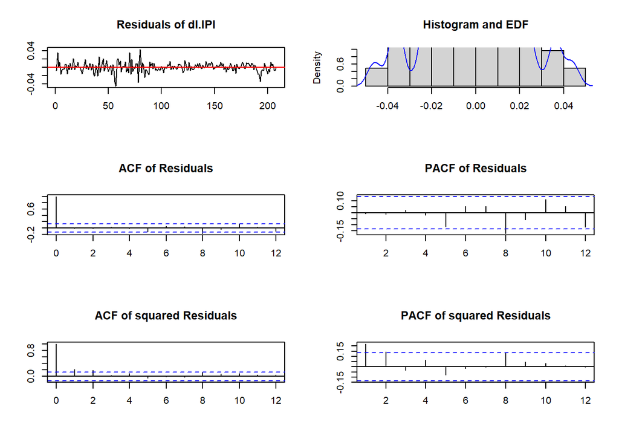

```r
plot(P.20.1, names = "dl.IPI")
```

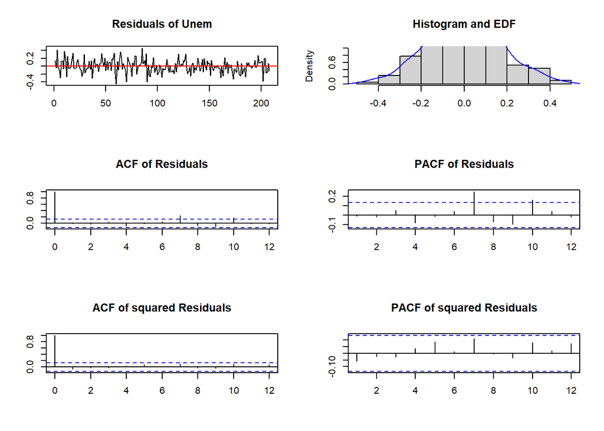

```r
plot(P.20.1, names = "Unem")
```

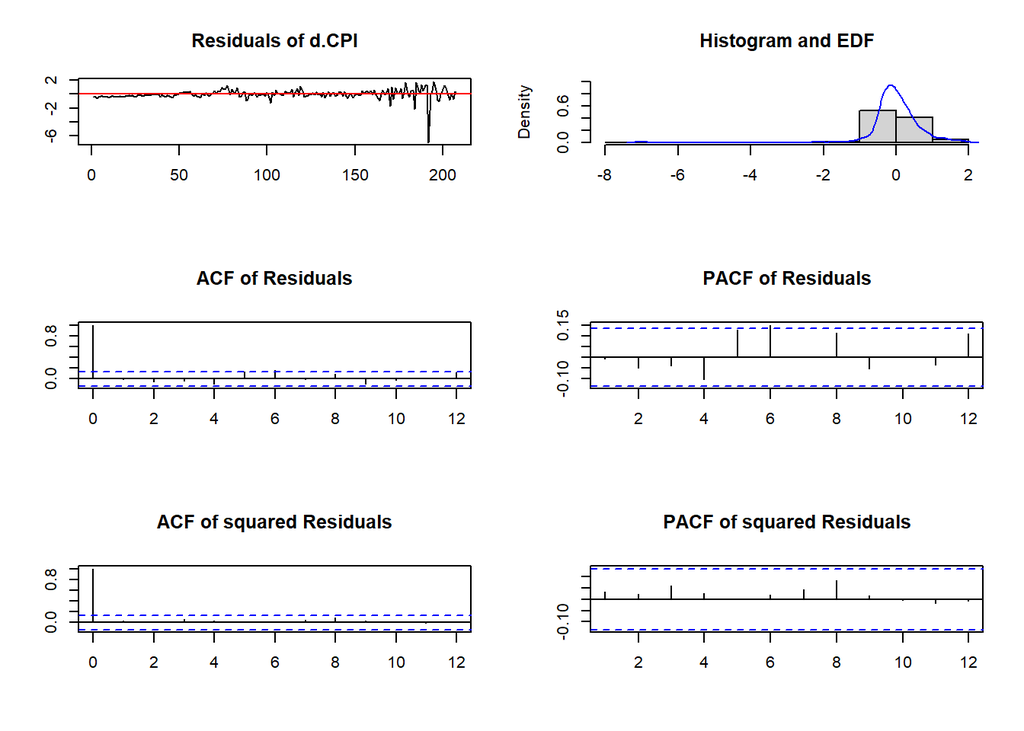

```r
plot(P.20.1, names= "d.CPI")
```

Los resiudales se comportan bastante bien, no obstante parece que no se comportan normalmente.

**Homocedasticidad:**

```r
arch.test(V.dr.1, lags.multi = 24, multivariate.only = TRUE) # rechazo H0
```

```
##
##  ARCH (multivariate)
##
## data:  Residuals of VAR object V.dr.1
## Chi-squared = 982.51, df = 864, p-value = 0.003016
```

```r
arch.test(V.dr.1, lags.multi = 12, multivariate.only = TRUE) # rechazo H0
```

```
##
##  ARCH (multivariate)
##
## data:  Residuals of VAR object V.dr.1
## Chi-squared = 593.5, df = 432, p-value = 3.698e-07
```

Se rechaza la hipótesis nula, luego, no se cumple el supuesto de homocedasticidad.

**Normalidad:**

```r
normality.test(V.dr.1)
```

```
## $JB
##
##  JB-Test (multivariate)
##
## data:  Residuals of VAR object V.dr.1
## Chi-squared = 15988, df = 6, p-value < 2.2e-16
##
##
## $Skewness
##
##  Skewness only (multivariate)
##
## data:  Residuals of VAR object V.dr.1
## Chi-squared = 634.06, df = 3, p-value < 2.2e-16
##
##
## $Kurtosis
##
##  Kurtosis only (multivariate)
##
## data:  Residuals of VAR object V.dr.1
## Chi-squared = 15354, df = 3, p-value < 2.2e-16
```

Rechazo, no se cumple el supuesto de normalidad.

## 3.4. Pronóstico y funciones de impulso respuesta

**Pronóstico:**

Para poder hacer inferencia en las IRF, pronósticos, etc, tenemos que usar Bootstrapping: son simulaciones de monte carlo que permiten calcular unos intervalos de confianza asintóticos a partir de los residuales de las regresiones.

El pronóstico es insesgado, pero no se pueden computar los intervalos de confianza de la manera convencional porque los residuales no son normales, por ende hay que hacer bootstrapping.

```r
predict(V.dr.1, n.ahead = 12)
```

```
## $dl.IPI
##              fcst       lower      upper         CI
##  [1,] 0.010709027 -0.01258076 0.03399881 0.02328979
##  [2,] 0.009553805 -0.01724258 0.03635019 0.02679639
##  [3,] 0.009022878 -0.01836585 0.03641161 0.02738873
##  [4,] 0.009835262 -0.01897313 0.03864366 0.02880840
##  [5,] 0.009912255 -0.01991707 0.03974159 0.02982933
##  [6,] 0.009611420 -0.02071197 0.03993481 0.03032339
##  [7,] 0.009491806 -0.02120904 0.04019266 0.03070085
##  [8,] 0.009342854 -0.02161236 0.04029807 0.03095522
##  [9,] 0.009125123 -0.02196847 0.04021871 0.03109359
## [10,] 0.008935524 -0.02224048 0.04011153 0.03117600
## [11,] 0.008764533 -0.02246627 0.03999534 0.03123080
## [12,] 0.008599740 -0.02267260 0.03987208 0.03127234
##
```

[output cut: 29 more lines]

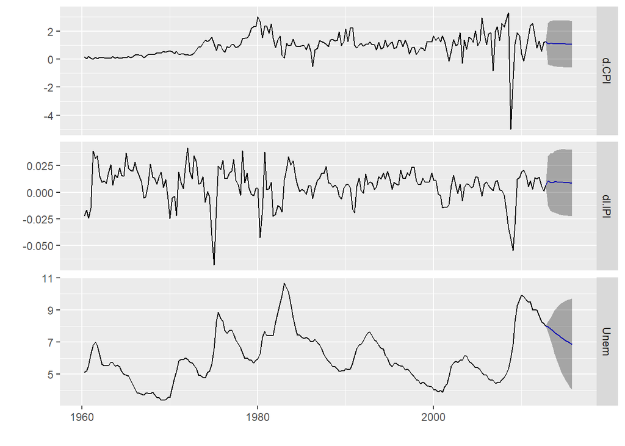

```r
autoplot(predict(V.dr.1, n.ahead = 12))
```

Para ello, Necesitamos estimar los intervalos de confianza por Bootstrapping

```r
library(VAR.etp)
For.Boot= VAR.BPR(Y, 3, 12, nboot = 1000, type = "const", alpha = 0.95)
For.Boot
```

```
## $Intervals
##     dl.IPI_lower dl.IPI_upper Unem_lower Unem_upper d.CPI_lower d.CPI_upper
## h1   -0.01066410   0.03511353   7.590534   8.273236  0.10962255    2.424693
## h2   -0.02149508   0.03626950   7.132237   8.480922  0.07012605    2.653629
## h3   -0.02064990   0.03804094   6.679655   8.794763 -0.27084147    2.473022
## h4   -0.01840372   0.04284628   6.140853   9.131100 -0.46970889    2.639008
## h5   -0.02094143   0.04365629   5.810415   9.239514 -0.45052870    2.359915
## h6   -0.02585076   0.04180407   5.438274   9.308261 -0.55925293    2.566649
## h7   -0.02031725   0.04157667   5.192516   9.271234 -0.40528554    2.493765
## h8   -0.02248141   0.04349966   4.901526   9.336694 -0.49497495    2.685806
## h9   -0.02661097   0.04309818   4.727396   9.475118 -0.57950508    2.656609
## h10  -0.02431475   0.04307631   4.372429   9.528194 -0.67354501    2.491973
## h11  -0.02270743   0.04515972   4.186819   9.692104 -0.36449603    2.527295
## h12  -0.02146553   0.04097494   3.980019   9.600414 -0.55209683    2.552140
##
## $Forecast
##          dl.IPI     Unem    d.CPI
## h1  0.010709027 7.957124 1.091199
## h2  0.009553805 7.839055 1.137509
## h3  0.009022878 7.730012 1.139802
## h4  0.009835262 7.625146 1.107179
## h5  0.009912255 7.513364 1.107204
## h6  0.009611420 7.402990 1.103375
## h7  0.009491806 7.298612 1.090666
## h8  0.009342854 7.199788 1.083562
## h9  0.009125123 7.107781 1.077553
## h10 0.008935524 7.023478 1.069809
## h11 0.008764533 6.946551 1.062949
## h12 0.008599740 6.876664 1.056887
##
## $Prob
## [1] 0.95
```

Veamos un gráfico puntual con Bootstrapping

```r
boots = For.Boot$Forecast
boots
```

```
##          dl.IPI     Unem    d.CPI
## h1  0.010709027 7.957124 1.091199
## h2  0.009553805 7.839055 1.137509
## h3  0.009022878 7.730012 1.139802
## h4  0.009835262 7.625146 1.107179
## h5  0.009912255 7.513364 1.107204
## h6  0.009611420 7.402990 1.103375
## h7  0.009491806 7.298612 1.090666
## h8  0.009342854 7.199788 1.083562
## h9  0.009125123 7.107781 1.077553
## h10 0.008935524 7.023478 1.069809
## h11 0.008764533 6.946551 1.062949
## h12 0.008599740 6.876664 1.056887
```

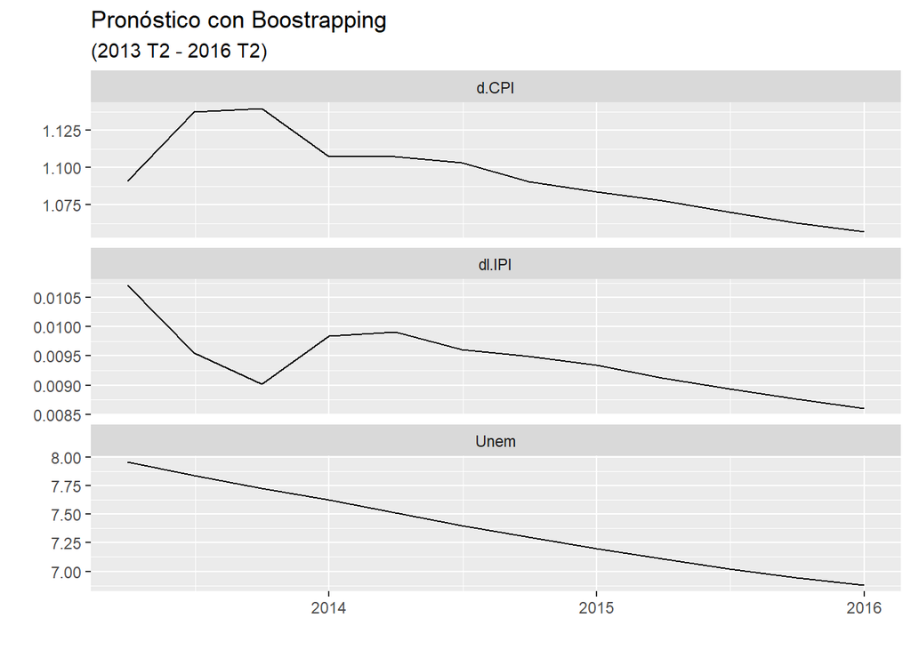

```r
boots.forecast = ts(boots, start = c(2013,2), freq = 4)
autoplot(boots.forecast, main = "Pronóstico con Boostrapping")+
  labs(subtitle = "(2013 T2 - 2016 T2)")
```

**Funciones de impulso respuesta:**

Análisis Impulso-Respuesta: ¿Qué efecto tiene un choque exógeno sobre una variable sobre las variables del sistema? todos los choques exógenos se incorporan/capturan en los residuales. Se parte del supuesto de Ceteris Paribus: los choques de una variable no deben correlacionarse con el de otra.

Como en economía los choques están generalmente correlacionados, usaremos la descomposición de Choleski para obtener las IRF ortogonales.

En este caso: el crecimiento del índice de producción industrial afecta contemporáneamente a la tasa desempleo y a la inflación. La tasa de desempleo afecta de forma contemporánea a la inflación pero no al crecimiento del IPI La tasa de inflación no afecta de forma contemporánea ni al crecimeinto del IPI ni al desempleo.

```r
pasos_adelantes = 0:24
```

IRF de las variables ante distintos choques ortogonales impulso respuesta: 1. calcula las IRF y 2. graficarlas.

```r
Y1.Y1. = impulso_respuesta(V.dr.1, "dl.IPI",
                           "dl.IPI", pasos_adelante, ortog = T, int_conf = 0.95,
                           titulo = "Imp. del crecimiento del IPI - res. del crecimiento del IPI")
Y1.Y2. = impulso_respuesta(V.dr.1, "dl.IPI",
                           "Unem", pasos_adelante, ortog = T, int_conf = 0.95,
                           titulo = "Imp. del crecimiento del IPI - resp. del desempleo")
Y1.Y3. = impulso_respuesta(V.dr.1, "dl.IPI",
                           "d.CPI", pasos_adelante, ortog = T, int_conf = 0.95,
                           titulo = "Imp. del crecimiento del IPI - resp. de la variación en CPI")
Y2.Y1. = impulso_respuesta(V.dr.1, "Unem",
                           "dl.IPI", pasos_adelante, ortog = T, int_conf = 0.95,
                           titulo = "Imp. tasa de desempleo - resp. del crecimiento del IPI")
Y2.Y2. = impulso_respuesta(V.dr.1, "Unem",
                           "Unem", pasos_adelante, ortog = T, int_conf = 0.95,
                           titulo = "Imp. de la tasa de desempleo - resp. tasa de desempleo")
Y2.Y3. = impulso_respuesta(V.dr.1, "Unem",
                           "d.CPI", pasos_adelante, ortog = T, int_conf = 0.95,
                           titulo = "Imp. de la tasa de desempleo - resp. de la variación en CPI")
Y3.Y1. = impulso_respuesta(V.dr.1, "d.CPI",
                           "dl.IPI", pasos_adelante, ortog = T, int_conf = 0.95,
                           titulo = "Imp. de la variación en CPI - resp. del crecimiento del IPI")
Y3.Y2. = impulso_respuesta(V.dr.1, "d.CPI",
                           "Unem", pasos_adelante, ortog = T, int_conf = 0.95,
                           titulo = "Imp. de la variación en CPI - resp. del desempleo")
Y3.Y3. = impulso_respuesta(V.dr.1, "d.CPI",
                           "d.CPI", pasos_adelante, ortog = T, int_conf = 0.95,
                           titulo = "Imp. de la variación en CPI - resp. de la variación en CPI")
```

Las IRF ORTOGONALES son:

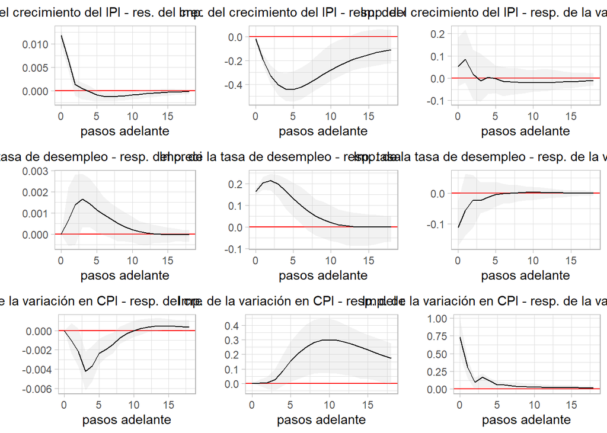

```r
grid.arrange(Y1.Y1., Y1.Y2., Y1.Y3., Y2.Y1., Y2.Y2., Y2.Y3., Y3.Y1., Y3.Y2., Y3.Y3., ncol=3)
```

**Descomposición de la varianza del error de pronóstico**

¿Qué proporción de la varianza del error de pronóstico del crecimiento del IPI se explica por el crecimiento del IPI, la tasa de desempleo y la variación del CPI? ¿Qué proporción de la varianza del error de pronóstico de la tasa de desempleo se explica por el crecimiento del IPI,la tasa de desempleo y la variación del CPI? ¿Qué proporción de la varianza del error de pronóstico de la variación del CPI se explica por el crecimiento del IPI,la tasa de desempleo y la variación del CPI?

```r
fevd(V.dr.1, n.ahead = 24)
```

```
## $dl.IPI
##          dl.IPI        Unem       d.CPI
##  [1,] 1.0000000 0.000000000 0.000000000
##  [2,] 0.9919637 0.002248167 0.005788155
##  [3,] 0.9585847 0.011861528 0.029553767
##  [4,] 0.8672135 0.023345411 0.109441064
##  [5,] 0.8090096 0.030731947 0.160258432
##  [6,] 0.7863065 0.035247522 0.178446017
##  [7,] 0.7728533 0.038001475 0.189145275
##  [8,] 0.7664062 0.039479113 0.194114705
##  [9,] 0.7653039 0.040143784 0.194552342
## [10,] 0.7657658 0.040387468 0.193846720
## [11,] 0.7664013 0.040431333 0.193167368
## [12,] 0.7667258 0.040384639 0.192889582
## [13,] 0.7666299 0.040310044 0.193060095
```

[output cut: 65 more lines]

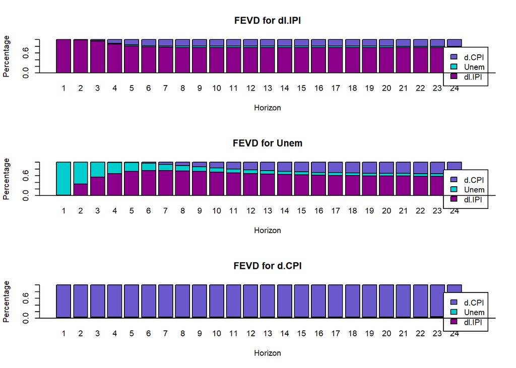

```r
plot(fevd(V.dr.1, n.ahead = 24),col=c("magenta4", "cyan3", "slateblue3"))
```

```r
Phi(V.dr.1,nstep=10)
```

```
## , , 1
##
##      [,1] [,2] [,3]
## [1,]    1    0    0
## [2,]    0    1    0
## [3,]    0    0    1
##
## , , 2
##
##             [,1]         [,2]         [,3]
## [1,]   0.5709307  0.002964271 -0.001419565
## [2,] -14.2839278  1.247456620  0.004821725
## [3,]   5.2673334 -0.049342216  0.422385649
##
## , , 3
##
##             [,1]         [,2]         [,3]
## [1,]   0.1358178  0.006336766 -0.002955334
## [2,] -25.5445777  1.308889069  0.010011810
## [3,]   0.7825789 -0.040261573  0.133626212
##
## , , 4
##
##              [,1]       [,2]         [,3]
## [1,]   0.07049782 0.00610673 -0.005769725
## [2,] -32.03555896 1.22358757  0.036025103
## [3,]  -1.96677725 0.01586700  0.225768634
##
## , , 5
##
##              [,1]        [,2]         [,3]
## [1,]   0.01603148 0.005341145 -0.005010044
## [2,] -35.56834541 1.089873943  0.120036379
## [3,]  -0.33211107 0.025685955  0.156799629
##
## , , 6
##
##             [,1]        [,2]         [,3]
## [1,]  -0.0539884 0.004772403 -0.003227679
## [2,] -36.4952681 0.941938752  0.210043903
```

[output cut: 21 more lines]

```
## [3,]  -1.68695949 0.047365782  0.046691639
##
## , , 10
##
##              [,1]        [,2]          [,3]
## [1,]  -0.08506804 0.001790313 -0.0003893167
## [2,] -27.53955926 0.471835764  0.4040767269
## [3,]  -1.86373197 0.046162976  0.0424073537
##
## , , 11
##
##              [,1]        [,2]         [,3]
## [1,]  -0.07509622 0.001319381 1.216038e-05
## [2,] -24.59741999 0.400356557 4.099140e-01
## [3,]  -1.88333434 0.043424053 3.874678e-02
```

La función psi nos calcula los coeficientes de las matrices de la representación VMA bajo una estrategia de identificación ortogonal. Es decir, son los coeficientes de las IRF ortogonales n pasos adelante

```r
Psi(V.dr.1,nstep=10)
```

```
## , , 1
##
##             [,1]       [,2]      [,3]
## [1,]  0.01188276  0.0000000 0.0000000
## [2,] -0.02006947  0.1655000 0.0000000
## [3,]  0.05288827 -0.1110644 0.7327283
##
## , , 2
##
##              [,1]          [,2]         [,3]
## [1,]  0.006649664  0.0006482498 -0.001040155
## [2,] -0.194513303  0.2059185022  0.003533014
## [3,]  0.085919990 -0.0550781258  0.309493901
##
## , , 3
##
##              [,1]         [,2]         [,3]
## [1,]  0.001330413  0.001376967 -0.002165457
## [2,] -0.329279351  0.215509137  0.007335936
## [3,]  0.017174487 -0.021504398  0.097911702
##
## , , 4
##
##               [,1]         [,2]         [,3]
## [1,]  0.0004099992  0.001651474 -0.004227641
## [2,] -0.4033223842  0.198502592  0.026396611
## [3,] -0.0117486760 -0.022448860  0.165427058
##
## , , 5
##
##               [,1]         [,2]         [,3]
## [1,] -0.0001816682  0.001440397 -0.003671001
## [2,] -0.4381748727  0.167042334  0.087954047
## [3,]  0.0038309609 -0.013163825  0.114891519
##
## , , 6
##
##               [,1]         [,2]         [,3]
## [1,] -0.0009080173  0.001148313 -0.002365012
## [2,] -0.4414599511  0.132562437  0.153905103
```

[output cut: 21 more lines]

```
## [3,] -0.018526905 0.002653258  0.0342122832
##
## , , 10
##
##              [,1]         [,2]          [,3]
## [1,] -0.001067364 0.0003395359 -0.0002852633
## [2,] -0.315344612 0.0332102791  0.2960784361
## [3,] -0.020829899 0.0029300253  0.0310730664
##
## , , 11
##
##               [,1]         [,2]         [,3]
## [1,] -0.0009181867 0.0002170069 8.910255e-06
## [2,] -0.2786405993 0.0207321650 3.003555e-01
## [3,] -0.0212014621 0.0028832933 2.839086e-02
```

Fin del código.